# Coral Skeletal Growth Analysis: Allometric Scaling and Fish Effects

Hayden Vega & Adrian Stier

2026-05-14

# Overview

## Study Design

**Research Question**: Do damselfish (*Dascyllus flavicaudus*) enhance coral skeletal growth rates in *Pocillopora* spp., and does this effect vary with wound size?

**Experimental Design**:

- **Factors**: Fish presence (Present/Absent) × Wound size (None/Small/Large)
- **Sample size**: 72 coral fragments
- **Duration**: 21 days
- **Location**: Mo’orea, French Polynesia
- **Response variables**:
  - Buoyant weight (skeletal mass)
  - Allometrically-scaled growth
  - Growth rate per surface area per day

## Analysis Overview

This document contains:

1. **Data Import & Preparation**
2. **Full Model Analysis** (ANCOVA-style with initial mass as covariate)
3. **Allometric Scaling Visualization** (size-corrected growth)
4. **Surface Area Growth Rate Analysis**
5. **Publication Figures**
6. **Comprehensive Diagnostics**

**Key Methodology**: We use an **ANCOVA-style approach** where log(initial mass) is included as a covariate in the full model with treatment effects. This:

- Estimates the allometric coefficient (*b*) without bias from treatment effects
- Tests treatment effects while properly controlling for initial coral size
- Avoids the two-step estimation problem of estimating *b* from pooled data

For visualization, we calculate size-corrected growth using the *b* from the full model.

# 1. Setup & Data Import

## Load Required Packages

```r
# ==================== Core Packages ====================
library(tidyverse)      # Data wrangling and visualization
library(here)           # Relative file paths
library(janitor)        # Data cleaning

# ==================== Statistical Modeling ====================
library(lme4)           # Linear mixed-effects models
library(DHARMa)         # Residual diagnostics
library(broom.mixed)    # Tidy model outputs

# ==================== Visualization ====================
library(ggpubr)         # Publication-ready plots
library(gt)             # Publication-quality tables

cat("✓ Packages loaded successfully\n")
```

```
## ✓ Packages loaded successfully
```

## Define Aesthetics

```r
# Consistent color schemes for all figures
# Designed for grayscale compatibility

wound_palette <- c(
  "Large" = "#FF8B00",     # Orange
  "Small" = "#be8333",     # Tan
  "No Wound" = "#485900"   # Olive green
)

# Fish palette: Colorblind-safe with high contrast
# Using darker teal and higher-chroma vermillion (Okabe-Ito inspired)
fish_palette <- c(
  "Fish" = "#0072B2",      # Strong blue (colorblind-safe)
  "No Fish" = "#D55E00"    # Vermillion/orange-red (high contrast)
)

# Fill palette for grayscale distinction
fish_fill_palette <- c(
  "Fish" = "#0072B2",      # Strong blue fill
  "No Fish" = "white"      # White fill (open appearance)
)
```

## Import Data

```r
# Import buoyant weight data (skeletal mass measurements)
bw_raw <- read_csv(here("data", "fish_regen_buoyantweight (1).csv")) %>%
  clean_names() %>%
  # Remove outliers identified in QC
  filter(coral_id != 45) %>%
  filter(coral_id != 91)

# Import surface area data
sa <- read_csv(here("data", "fish_regen_mastersheet_wound closure_necrosis_sa - mastersheet.csv")) %>%
  clean_names() %>%
  mutate(coral_id = as.character(coral_id))

# Import tank metadata
tank_df <- read_csv(here("data", "Copy of fish_regen_mastersheet_wound closure_necrosis - mastersheet.csv")) %>%
  clean_names() %>%
  select(coral_id, tank) %>%
  mutate(coral_id = as.character(coral_id))

cat("✓ Data imported successfully\n")
```

```
## ✓ Data imported successfully
```

```r
cat("  - Buoyant weight data:", nrow(bw_raw), "observations\n")
```

```
##   - Buoyant weight data: 134 observations
```

```r
cat("  - Surface area data:", nrow(sa), "corals\n")
```

```
##   - Surface area data: 72 corals
```

```r
cat("  - Tank assignments:", nrow(tank_df), "corals\n")
```

```
##   - Tank assignments: 72 corals
```

# 2. Data Preparation

## Reshape Buoyant Weight Data

```r
# Split data into initial and final measurements
bw_initial <- bw_raw %>%
  filter(date == "initial") %>%
  select(coral_id, wound, fish, initial_weight = bouyantweight_g)

bw_final <- bw_raw %>%
  filter(date == "final") %>%
  select(coral_id, final_weight = bouyantweight_g)

# Join into wide format (one row per coral)
bw_wide <- left_join(bw_initial, bw_final, by = "coral_id") %>%
  mutate(
    delta_mass = final_weight - initial_weight,
    coral_id = as.character(coral_id)
  )

cat("✓ Data reshaped to wide format\n")
```

```
## ✓ Data reshaped to wide format
```

```r
cat("  - Initial weights:", sum(!is.na(bw_wide$initial_weight)), "corals\n")
```

```
##   - Initial weights: 67 corals
```

```r
cat("  - Final weights:", sum(!is.na(bw_wide$final_weight)), "corals\n")
```

```
##   - Final weights: 67 corals
```

## Merge with Surface Area Data

```r
# Adjust surface area to account for wound area removed
sa_adjusted <- sa %>%
  select(-fish, -date_collected, -date_fragment) %>%
  mutate(
    # Subtract wound area: 3 cm² for large wounds, 1 cm² for small
    sa_col = ifelse(wound == "Large", sa_cal - 3,
                    ifelse(wound == "Small", sa_cal - 1, sa_cal))
  ) %>%
  select(-wound)  # Remove to avoid duplication in join

# Merge buoyant weight with adjusted surface area
bw_sa_wide <- left_join(bw_wide, sa_adjusted, by = "coral_id") %>%
  mutate(
    wound = factor(wound, levels = c("No Wound", "Small", "Large")),
    tank = as.factor(tank)
  ) %>%
  mutate(tank = factor(tank, levels = sort(unique(as.numeric(as.character(tank))))))
# Prepare clean dataset
bw_sa_df <- bw_sa_wide %>%
  drop_na(initial_weight, final_weight, wound) %>%
  filter(coral_id != 103) %>%  # Remove outlier
  mutate(
    delta_mass = final_weight - initial_weight,
    wound = factor(wound, levels = c("No Wound", "Small", "Large"))
  )

cat("✓ Surface area data merged\n")
```

```
## ✓ Surface area data merged
```

```r
cat("  - Mean initial SA:", round(mean(bw_sa_wide$sa_cal, na.rm = TRUE), 2), "cm²\n")
```

```
##   - Mean initial SA: 69.38 cm²
```

## Merge with Tank Metadata

```r
bw_merged <- left_join(bw_wide, tank_df, by = "coral_id") %>%
  mutate(
    wound = factor(wound, levels = c("No Wound", "Small", "Large")),
    tank = as.factor(tank)
  )

cat("✓ Tank metadata merged\n")
```

```
## ✓ Tank metadata merged
```

```r
cat("  - Number of tanks:", nlevels(bw_merged$tank), "\n")
```

```
##   - Number of tanks: 6
```

# 3. Allometric Scaling Analysis

## Theory: Why Allometric Scaling?

**Problem**: Larger corals grow faster simply because they’re bigger, not necessarily because they’re healthier.

**Solution**: We use an ANCOVA-style approach where we include log(initial mass) as a covariate in our full model with treatment effects. This simultaneously:

1. Estimates the allometric coefficient (*b*) while accounting for treatment effects
2. Tests treatment effects while controlling for initial size

The model structure is:

$$\log(\text{Final Mass}) = \alpha + b
\times \log(\text{Initial Mass}) + \text{Fish} + \text{Wound} +
\text{Fish} \times \text{Wound} + \text{Tank}$$

This approach avoids the bias that would occur if we estimated *b* from a pooled model ignoring treatments (see Osenberg & Mittlebach 1989; Packard & Boardman 1999).

For visualization, we calculate **size-corrected growth** using the *b* from the full model:

$$\text{Scaled Growth} =
\log\left(\frac{\text{Final Mass}}{\text{Initial
Mass}^b}\right)$$

## Prepare Data for Allometric Model

```r
# Create dataset with log-transformed weights
log_df <- bw_sa_df %>%
  mutate(
    log_i_weight = log(initial_weight),
    log_f_weight = log(final_weight),
    growth_ratio = final_weight / initial_weight
  ) %>%
  drop_na(log_i_weight, log_f_weight, tank)

cat("✓ Allometric dataset prepared\n")
```

```
## ✓ Allometric dataset prepared
```

```r
cat("  - Valid observations:", nrow(log_df), "corals\n")
```

```
##   - Valid observations: 66 corals
```

## Fit Full Model with Treatment Effects

This is our **primary analysis**. We fit a single model that includes initial mass as a covariate along with treatment effects. This approach:

- Estimates the allometric coefficient (*b*) without bias from treatment effects
- Directly tests treatment effects while controlling for initial size
- Provides the most statistically rigorous inference

```r
# Full model: includes initial mass AND treatment effects
# This is the primary analysis - treatment effects are tested here
model_full <- lmer(
  log_f_weight ~ log_i_weight + fish * wound + (1 | tank),
  data = log_df,
  REML = FALSE  # Use ML for likelihood ratio tests
)

cat("=== Full Model Summary (Primary Analysis) ===\n")
```

```
## === Full Model Summary (Primary Analysis) ===
```

```r
summary(model_full)
```

```
## Linear mixed model fit by maximum likelihood  ['lmerMod']
## Formula: log_f_weight ~ log_i_weight + fish * wound + (1 | tank)
##    Data: log_df
##
##       AIC       BIC    logLik -2*log(L)  df.resid
##    -520.4    -500.7     269.2    -538.4        57
##
## Scaled residuals:
##     Min      1Q  Median      3Q     Max
## -3.2486 -0.7558  0.1102  0.6067  2.4703
##
## Random effects:
##  Groups   Name        Variance  Std.Dev.
##  tank     (Intercept) 0.000e+00 0.000000
##  Residual             1.678e-05 0.004097
## Number of obs: 66, groups:  tank, 6
##
## Fixed effects:
##                          Estimate Std. Error t value
## (Intercept)             0.0446301  0.0051076   8.738
## log_i_weight            0.9899499  0.0018481 535.663
## fishNo Fish             0.0003629  0.0017570   0.207
## woundSmall              0.0006992  0.0017541   0.399
## woundLarge              0.0026680  0.0017920   1.489
## fishNo Fish:woundSmall  0.0021884  0.0024513   0.893
## fishNo Fish:woundLarge -0.0035677  0.0025090  -1.422
##
## Correlation of Fixed Effects:
##             (Intr) lg__wg fshNFs wndSml wndLrg fsNF:S
## log_i_weght -0.967
## fishNo Fish -0.131 -0.058
## woundSmall  -0.184 -0.004  0.545
## woundLarge  -0.138 -0.047  0.536  0.534
## fshNFsh:wnS  0.169 -0.036 -0.712 -0.715 -0.380
## fshNFsh:wnL  0.085  0.048 -0.701 -0.382 -0.715  0.499
## optimizer (nloptwrap) convergence code: 0 (OK)
## boundary (singular) fit: see help('isSingular')
```

```r
# Extract allometric coefficient (b-value) with 95% CI
b_value <- tidy(model_full, effects = "fixed", conf.int = TRUE) %>%
  filter(term == "log_i_weight")

cat("\n=== Allometric Coefficient (b-value) from Full Model ===\n")
```

```
##
## === Allometric Coefficient (b-value) from Full Model ===
```

```r
print(b_value)
```

```
## # A tibble: 1 × 7
##   effect term         estimate std.error statistic conf.low conf.high
##   <chr>  <chr>           <dbl>     <dbl>     <dbl>    <dbl>     <dbl>
## 1 fixed  log_i_weight    0.990   0.00185      536.    0.986     0.994
```

```r
# Extract all fixed effects for reporting
cat("\n=== All Fixed Effects ===\n")
```

```
##
## === All Fixed Effects ===
```

```r
print(tidy(model_full, effects = "fixed", conf.int = TRUE))
```

```
## # A tibble: 7 × 7
##   effect term                    estimate std.error statistic conf.low conf.high
##   <chr>  <chr>                      <dbl>     <dbl>     <dbl>    <dbl>     <dbl>
## 1 fixed  (Intercept)             0.0446     0.00511     8.74   3.46e-2   0.0546
## 2 fixed  log_i_weight            0.990      0.00185   536.     9.86e-1   0.994
## 3 fixed  fishNo Fish             0.000363   0.00176     0.207 -3.08e-3   0.00381
## 4 fixed  woundSmall              0.000699   0.00175     0.399 -2.74e-3   0.00414
## 5 fixed  woundLarge              0.00267    0.00179     1.49  -8.44e-4   0.00618
## 6 fixed  fishNo Fish:woundSmall  0.00219    0.00245     0.893 -2.62e-3   0.00699
## 7 fixed  fishNo Fish:woundLarge -0.00357    0.00251    -1.42  -8.49e-3   0.00135
```

## Likelihood Ratio Tests for Treatment Effects

We test the significance of treatment effects using likelihood ratio tests comparing nested models.

```r
# Fit reduced models for comparison (all with REML = FALSE)
model_no_interaction <- lmer(
  log_f_weight ~ log_i_weight + fish + wound + (1 | tank),
  data = log_df, REML = FALSE
)

model_no_fish <- lmer(
  log_f_weight ~ log_i_weight + wound + (1 | tank),
  data = log_df, REML = FALSE
)

model_no_wound <- lmer(
  log_f_weight ~ log_i_weight + fish + (1 | tank),
  data = log_df, REML = FALSE
)

# Likelihood ratio tests
lrt_interaction <- anova(model_no_interaction, model_full, test = "Chisq")
lrt_fish <- anova(model_no_fish, model_no_interaction, test = "Chisq")
lrt_wound <- anova(model_no_wound, model_no_interaction, test = "Chisq")

# Compile results
lrt_table_full <- tibble(
  Test = c("Interaction (Fish × Wound)", "Fish Effect", "Wound Effect"),
  ChiSq = c(lrt_interaction$Chisq[2], lrt_fish$Chisq[2], lrt_wound$Chisq[2]),
  Df = c(lrt_interaction$Df[2], lrt_fish$Df[2], lrt_wound$Df[2]),
  p_value = c(lrt_interaction$`Pr(>Chisq)`[2], lrt_fish$`Pr(>Chisq)`[2], lrt_wound$`Pr(>Chisq)`[2])
) %>%
  mutate(across(where(is.numeric), round, 3))

# Format as publication table
lrt_table_full %>%
  gt() %>%
  tab_header(
    title = "Likelihood Ratio Tests: Treatment Effects on Growth",
    subtitle = "Full model with log(initial mass) as covariate"
  ) %>%
  cols_label(
    Test = "Model Comparison",
    ChiSq = "χ²",
    Df = "df",
    p_value = "P-value"
  ) %>%
  fmt_number(columns = c(ChiSq, p_value), decimals = 3) %>%
  tab_style(
    style = cell_text(weight = "bold"),
    locations = cells_body(
      columns = p_value,
      rows = p_value < 0.05
    )
  ) %>%
  tab_options(
    table.font.size = 14,
    heading.title.font.size = 16
  )
```

Likelihood Ratio Tests: Treatment Effects on Growth

Full model with log(initial mass) as covariate

| Model Comparison | χ² | df | P-value |
| --- | --- | --- | --- |
| Interaction (Fish × Wound) | 5.224 | 2 | 0.073 |
| Fish Effect | 0.001 | 1 | 0.978 |
| Wound Effect | 1.783 | 2 | 0.410 |

## Visualize Allometric Relationship

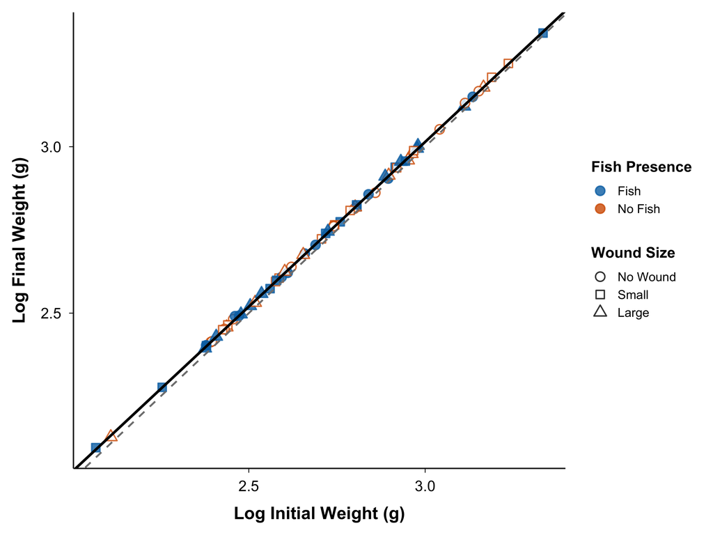

```r
# Generate predicted values from full model (population-level, no random effects)
# Use mean values for treatment factors to show overall allometric relationship
fit_df <- log_df %>%
  select(log_i_weight) %>%
  distinct() %>%
  arrange(log_i_weight)

# Get the b-value (slope) from full model
b_est <- fixef(model_full)["log_i_weight"]
intercept_est <- fixef(model_full)["(Intercept)"]

# Create allometric scaling plot - publication quality
# Grayscale compatible: No Fish = white fill, Fish = dark fill
allometric_plot <- ggplot(log_df, aes(x = log_i_weight, y = log_f_weight)) +
  geom_point(aes(color = fish, fill = fish, shape = wound), size = 3, alpha = 0.8, stroke = 0.8) +
  geom_abline(
    intercept = intercept_est,
    slope = b_est,
    color = "black",
    linewidth = 1
  ) +
  geom_abline(intercept = 0, slope = 1, linetype = "dashed",
              color = "gray50", linewidth = 0.7) +
  scale_color_manual(
    values = c("No Fish" = "#D55E00", "Fish" = "#0072B2"),
    name = "Fish Presence"
  ) +
  scale_fill_manual(
    values = c("No Fish" = "white", "Fish" = "#0072B2"),
    name = "Fish Presence"
  ) +
  scale_shape_manual(
    values = c("No Wound" = 21, "Small" = 22, "Large" = 24),  # Fillable shapes
    name = "Wound Size"
  ) +
  labs(
    x = "Log Initial Weight (g)",
    y = "Log Final Weight (g)"
  ) +
  theme_minimal(base_size = 14) +
  theme(
    panel.grid = element_blank(),
    axis.title.x = element_text(size = 14, face = "bold", margin = margin(t = 10)),
    axis.title.y = element_text(size = 14, face = "bold", margin = margin(r = 10)),
    axis.text = element_text(size = 12, color = "black"),
    legend.position = "right",
    legend.title = element_text(size = 12, face = "bold"),
    legend.text = element_text(size = 10),
    legend.key.size = unit(1, "lines"),
    legend.spacing.y = unit(0.3, "cm"),
    axis.line = element_line(color = "black", linewidth = 0.5),
    axis.ticks = element_line(color = "black", linewidth = 0.3),
    plot.margin = margin(10, 10, 10, 10)
  ) +
  guides(
    color = guide_legend(order = 1, override.aes = list(size = 3)),
    fill = guide_legend(order = 1, override.aes = list(size = 3)),
    shape = guide_legend(order = 2, override.aes = list(size = 3))
  )

print(allometric_plot)
```

```r
# Save figure
ggsave(
  filename = here("figures", "growth", "allometric_scaling_plot.pdf"),
  plot = allometric_plot,
  width = 8, height = 6, dpi = 600, device = cairo_pdf
)

ggsave(
  filename = here("figures", "growth", "allometric_scaling_plot.png"),
  plot = allometric_plot,
  width = 10, height = 7.5, dpi = 300, bg = "white"
)

cat("✓ Allometric plot saved\n")
```

```
## ✓ Allometric plot saved
```

## Display b-value Table

```r
# Create formatted table of allometric coefficient from full model
b_value_gt <- tidy(model_full, effects = "fixed", conf.int = TRUE) %>%
  filter(term == "log_i_weight") %>%
  transmute(
    Term = "Allometric slope (b-value)",
    Estimate = round(estimate, 3),
    `95% CI` = paste0("[", round(conf.low, 3), ", ", round(conf.high, 3), "]")
  )

b_value_gt %>%
  gt() %>%
  tab_header(
    title = "Estimated Allometric Slope",
    subtitle = "From full model including treatment effects"
  ) %>%
  cols_label(
    Term = "",
    Estimate = "Estimate",
    `95% CI` = "95% Confidence Interval"
  ) %>%
  tab_options(
    table.font.size = 14,
    heading.title.font.size = 16,
    heading.subtitle.font.size = 13
  )
```

Estimated Allometric Slope

From full model including treatment effects

|  | Estimate | 95% Confidence Interval |
| --- | --- | --- |
| Allometric slope (b-value) | 0.99 | [0.986, 0.994] |

# 4. Surface Area Growth Analysis

## Prepare SA-Adjusted Dataset

```r
# Create dataset with surface area and time adjustments

bw_sa_stats <- log_df %>%
  drop_na(initial_weight, final_weight, fish, wound, tank) %>%
  mutate(
    wound = factor(wound, levels = c("No Wound", "Small", "Large")),
    fish = factor(fish),
    tank = factor(tank),
    # Growth rate: mass change per surface area per day
    # Using delta_mass (g) / surface area (cm²) / time (days)
    bw_sa_time = delta_mass / (sa_cal * 21)
  )

cat("✓ SA-adjusted growth data prepared\n")
```

```
## ✓ SA-adjusted growth data prepared
```

```r
cat("  - Valid observations:", nrow(bw_sa_stats), "corals\n")
```

```
##   - Valid observations: 66 corals
```

```r
cat("  - Mean growth rate:", round(mean(bw_sa_stats$bw_sa_time, na.rm = TRUE), 5), "g/cm²/day\n")
```

```
##   - Mean growth rate: 0.00021 g/cm²/day
```

## Visualize SA-Growth Relationship

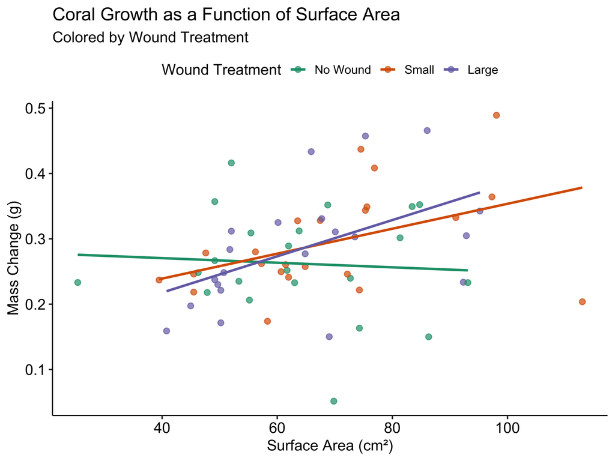

```r
sa_growth_plot <- ggplot(bw_sa_stats, aes(x = sa_cal, y = delta_mass, color = wound)) +
  geom_point(size = 2.2, alpha = 0.7) +
  geom_smooth(method = "lm", se = FALSE, linewidth = 1.1) +
  scale_color_brewer(palette = "Dark2") +
  labs(
    title = "Coral Growth as a Function of Surface Area",
    subtitle = "Colored by Wound Treatment",
    x = "Surface Area (cm²)",
    y = "Mass Change (g)",
    color = "Wound Treatment"
  ) +
  theme_pubr(base_size = 14)

print(sa_growth_plot)
```

```r
# Save figure
ggsave(
  filename = here("figures", "growth", "sa_growth_relationship.pdf"),
  plot = sa_growth_plot,
  width = 8, height = 6, dpi = 600, device = cairo_pdf
)

ggsave(
  filename = here("figures", "growth", "sa_growth_relationship.png"),
  plot = sa_growth_plot,
  width = 10, height = 7.5, dpi = 300, bg = "white"
)

cat("✓ SA-growth plot saved\n")
```

```
## ✓ SA-growth plot saved
```

# 5. Scaled Growth for Visualization

## Calculate Scaled Growth Variable

For visualization purposes, we calculate size-corrected growth using the *b*-value from the full model. This allows us to plot growth rates that are adjusted for initial coral size.

Note: The **primary statistical inference** comes from the full model in Section 3, which directly tests treatment effects while controlling for initial mass. The scaled growth variable here is for visualization only.

```r
# Extract b-value from full model (already calculated above)
# b_est was defined in the plot-allometric chunk

# Calculate allometrically-scaled growth for visualization
growth_stats <- log_df %>%
  drop_na(initial_weight, final_weight, fish, wound, tank) %>%
  mutate(
    wound = factor(wound, levels = c("No Wound", "Small", "Large")),
    fish = factor(fish, levels = c("No Fish", "Fish")),
    tank = factor(tank),
    # Size-corrected growth using estimated b-value from full model
    growth_scaled = log(final_weight / initial_weight^b_est)
  )

cat("✓ Scaled growth variable calculated\n")
```

```
## ✓ Scaled growth variable calculated
```

```r
cat("  - Using b-value from full model:", round(b_est, 3), "\n")
```

```
##   - Using b-value from full model: 0.99
```

```r
cat("  - Mean scaled growth:", round(mean(growth_stats$growth_scaled, na.rm = TRUE), 4), "\n")
```

```
##   - Mean scaled growth: 0.0457
```

## Summary Statistics: Scaled Growth by Treatment

```r
# Summary by fish
scaled_by_fish <- growth_stats %>%
  group_by(fish) %>%
  summarize(
    mean_scaled = mean(growth_scaled, na.rm = TRUE),
    sd_scaled = sd(growth_scaled, na.rm = TRUE),
    n = n(),
    .groups = "drop"
  )

cat("\n=== Scaled Growth by Fish Presence ===\n")
```

```
##
## === Scaled Growth by Fish Presence ===
```

```r
print(scaled_by_fish)
```

```
## # A tibble: 2 × 4
##   fish    mean_scaled sd_scaled     n
##   <fct>         <dbl>     <dbl> <int>
## 1 No Fish      0.0457   0.00421    33
## 2 Fish         0.0458   0.00456    33
```

```r
# Summary by wound
scaled_by_wound <- growth_stats %>%
  group_by(wound) %>%
  summarize(
    mean_scaled = mean(growth_scaled, na.rm = TRUE),
    sd_scaled = sd(growth_scaled, na.rm = TRUE),
    n = n(),
    .groups = "drop"
  )

cat("\n=== Scaled Growth by Wound Size ===\n")
```

```
##
## === Scaled Growth by Wound Size ===
```

```r
print(scaled_by_wound)
```

```
## # A tibble: 3 × 4
##   wound    mean_scaled sd_scaled     n
##   <fct>          <dbl>     <dbl> <int>
## 1 No Wound      0.0448   0.00500    22
## 2 Small         0.0465   0.00362    23
## 3 Large         0.0458   0.00439    21
```

```r
# Summary by interaction
scaled_by_interaction <- growth_stats %>%
  group_by(fish, wound) %>%
  summarize(
    mean_scaled = mean(growth_scaled, na.rm = TRUE),
    sd_scaled = sd(growth_scaled, na.rm = TRUE),
    n = n(),
    .groups = "drop"
  )

cat("\n=== Scaled Growth by Fish × Wound ===\n")
```

```
##
## === Scaled Growth by Fish × Wound ===
```

```r
print(scaled_by_interaction)
```

```
## # A tibble: 6 × 5
##   fish    wound    mean_scaled sd_scaled     n
##   <fct>   <fct>          <dbl>     <dbl> <int>
## 1 No Fish No Wound      0.0450   0.00510    12
## 2 No Fish Small         0.0479   0.00248    11
## 3 No Fish Large         0.0441   0.00386    10
## 4 Fish    No Wound      0.0446   0.00515    10
## 5 Fish    Small         0.0453   0.00415    12
## 6 Fish    Large         0.0473   0.00444    11
```

# 6. Growth Rate Analysis (Scaled Growth/SA/Time)

## Fit Growth Rate Models

```r
# All models fit by maximum likelihood (REML = FALSE) for LRT validity
# (per reviewer 1 request, RSBL-2026-0177 revision). The allometric ANCOVA
# model_full above was already ML-fit and is the primary growth analysis;
# these per-SA-per-day models are a secondary parameterization.

# Full model with interaction
mod_int_sa <- lmer(bw_sa_time ~ fish * wound + (1 | tank),
                   data = bw_sa_stats, REML = FALSE)

# Additive model
mod_add_sa <- lmer(bw_sa_time ~ fish + wound + (1 | tank),
                   data = bw_sa_stats, REML = FALSE)

# Fish-only
mod_fish_sa <- lmer(bw_sa_time ~ fish + (1 | tank),
                    data = bw_sa_stats, REML = FALSE)

# Wound-only
mod_wound_sa <- lmer(bw_sa_time ~ wound + (1 | tank),
                     data = bw_sa_stats, REML = FALSE)

# Null
mod_null_sa <- lmer(bw_sa_time ~ 1 + (1 | tank),
                    data = bw_sa_stats, REML = FALSE)

cat("✓ Growth rate models fitted (ML / REML = FALSE)\n")
```

```
## ✓ Growth rate models fitted (ML / REML = FALSE)
```

## Growth Rate Model Comparison

```r
# Likelihood ratio tests
lrt_interaction_sa <- anova(mod_add_sa, mod_int_sa, test = "Chisq")
lrt_fish_sa <- anova(mod_wound_sa, mod_add_sa, test = "Chisq")
lrt_wound_sa <- anova(mod_fish_sa, mod_add_sa, test = "Chisq")

# Compile results
lrt_table_sa <- tibble(
  Test = c("Interaction (Fish × Wound)", "Fish Effect", "Wound Effect"),
  ChiSq = c(lrt_interaction_sa$Chisq[2], lrt_fish_sa$Chisq[2], lrt_wound_sa$Chisq[2]),
  Df = c(lrt_interaction_sa$Df[2], lrt_fish_sa$Df[2], lrt_wound_sa$Df[2]),
  p_value = c(lrt_interaction_sa$`Pr(>Chisq)`[2], lrt_fish_sa$`Pr(>Chisq)`[2], lrt_wound_sa$`Pr(>Chisq)`[2])
) %>%
  mutate(across(where(is.numeric), round, 3))

# Format table
lrt_table_sa %>%
  gt() %>%
  tab_header(
    title = "Likelihood Ratio Tests: Growth Rate (g/cm²/day)"
  ) %>%
  cols_label(
    Test = "Model Comparison",
    ChiSq = "χ²",
    Df = "df",
    p_value = "P-value"
  ) %>%
  fmt_number(columns = c(ChiSq, p_value), decimals = 3) %>%
  tab_options(
    table.font.size = 14,
    heading.title.font.size = 16
  )
```

Likelihood Ratio Tests: Growth Rate (g/cm²/day)

| Model Comparison | χ² | df | P-value |
| --- | --- | --- | --- |
| Interaction (Fish × Wound) | 3.051 | 2 | 0.218 |
| Fish Effect | 0.058 | 1 | 0.809 |
| Wound Effect | 0.228 | 2 | 0.892 |

# 7. Publication Figure: Growth Rate

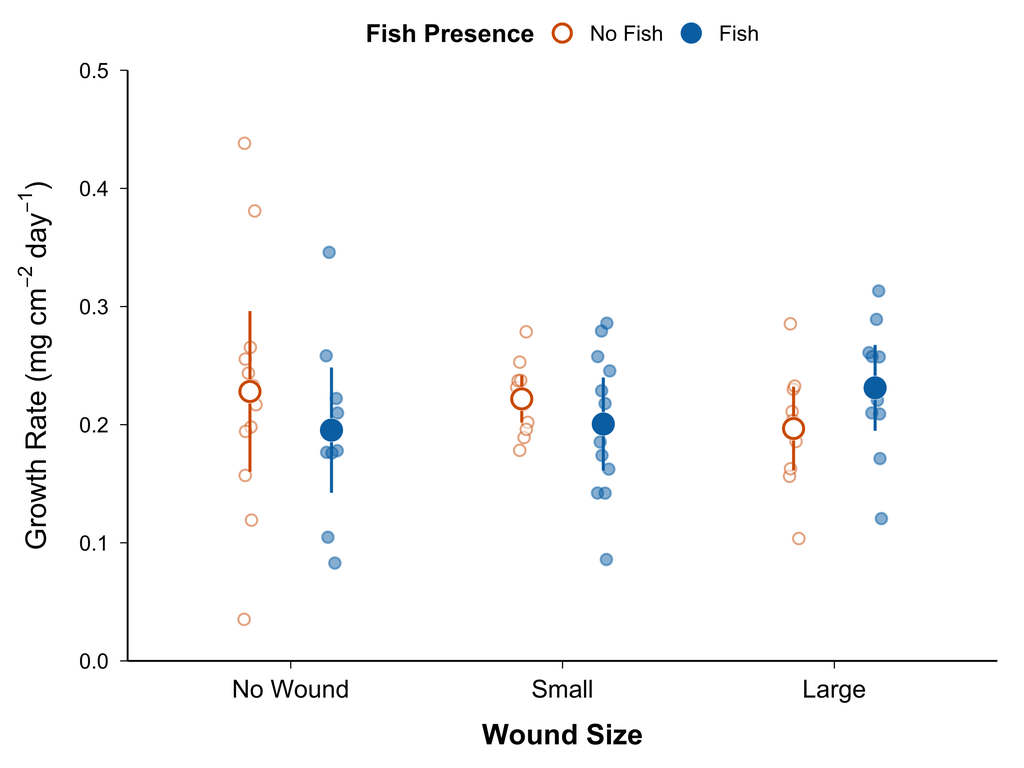

```r
# Prepare data with correct factor ordering
bw_sa_stats$wound <- factor(bw_sa_stats$wound, levels = c("No Wound", "Small", "Large"))
bw_sa_stats$fish <- factor(bw_sa_stats$fish, levels = c("No Fish", "Fish"))

# Prepare data in mg for readability
bw_sa_stats$bw_sa_time <- bw_sa_stats$bw_sa_time * 1000

# Calculate summary statistics for plotting
growth_summary <- bw_sa_stats %>%
  group_by(wound, fish) %>%
  summarize(
    mean_val = mean(bw_sa_time),
    sd_val = sd(bw_sa_time),
    n = n(),
    se = sd_val / sqrt(n),
    ci = qt(0.975, df = n - 1) * se,
    ci_lower = mean_val - ci,
    ci_upper = mean_val + ci,
    .groups = "drop"
  )

# Define gap size around mean point (in data units)
# This creates space so whiskers don't pass through the mean point
gap_size <- 0.008  # Adjust based on y-axis scale

# Create publication-quality figure
# Grayscale compatible: No Fish = white fill, Fish = dark fill
growth_rate_plot <- bw_sa_stats %>%
  ggplot(aes(x = wound, y = bw_sa_time, color = fish, fill = fish, shape = fish)) +

  # Individual data points with solid white fill for No Fish
  geom_jitter(
    position = position_jitterdodge(jitter.width = 0.1, dodge.width = 0.6),
    size = 2.5,
    alpha = 0.5,
    stroke = 0.8
  ) +

  # Lower whisker (from CI lower bound to just below mean)
  geom_segment(
    data = growth_summary,
    aes(x = as.numeric(wound) + ifelse(fish == "No Fish", -0.15, 0.15),
        xend = as.numeric(wound) + ifelse(fish == "No Fish", -0.15, 0.15),
        y = ci_lower, yend = mean_val - gap_size,
        color = fish),
    linewidth = 0.8,
    inherit.aes = FALSE,
    show.legend = FALSE
  ) +

  # Upper whisker (from just above mean to CI upper bound)
  geom_segment(
    data = growth_summary,
    aes(x = as.numeric(wound) + ifelse(fish == "No Fish", -0.15, 0.15),
        xend = as.numeric(wound) + ifelse(fish == "No Fish", -0.15, 0.15),
        y = mean_val + gap_size, yend = ci_upper,
        color = fish),
    linewidth = 0.8,
    inherit.aes = FALSE,
    show.legend = FALSE
  ) +

  # White outline behind mean points for visibility
  geom_point(
    data = growth_summary,
    aes(x = as.numeric(wound) + ifelse(fish == "No Fish", -0.15, 0.15),
        y = mean_val),
    size = 5.5,
    color = "white",
    inherit.aes = FALSE,
    show.legend = FALSE
  ) +

  # Mean points with solid fill
  geom_point(
    data = growth_summary,
    aes(x = as.numeric(wound) + ifelse(fish == "No Fish", -0.15, 0.15),
        y = mean_val, color = fish, fill = fish, shape = fish),
    size = 4.5,
    stroke = 1.2,
    inherit.aes = FALSE
  ) +

  # Scales - colorblind-safe with high contrast
  scale_color_manual(
    values = c("No Fish" = "#D55E00", "Fish" = "#0072B2"),
    name = "Fish Presence"
  ) +
  scale_fill_manual(
    values = c("No Fish" = "white", "Fish" = "#0072B2"),
    name = "Fish Presence"
  ) +
  scale_shape_manual(
    values = c("No Fish" = 21, "Fish" = 21),  # Both use fillable circles
    name = "Fish Presence"
  ) +
  scale_y_continuous(
    limits = c(0, 0.5),
    breaks = seq(0, 0.5, by = 0.1),
    expand = c(0, 0)
  ) +

  # Theme - publication quality

  theme_minimal(base_size = 14) +
  theme(
    panel.grid = element_blank(),
    axis.title.x = element_text(size = 16, face = "bold", margin = margin(t = 12)),
    axis.title.y = element_text(size = 16, face = "bold", margin = margin(r = 12)),
    axis.text.x = element_text(size = 14, color = "black"),
    axis.text.y = element_text(size = 12, color = "black"),
    legend.position = "top",
    legend.title = element_text(size = 14, face = "bold"),
    legend.text = element_text(size = 12),
    legend.key.size = unit(1.2, "lines"),
    legend.margin = margin(0, 0, 8, 0),
    legend.box.spacing = unit(0.3, "lines"),
    legend.background = element_rect(fill = "white", color = NA),
    axis.line = element_line(color = "black", linewidth = 0.5),
    axis.ticks = element_line(color = "black", linewidth = 0.3),
    axis.ticks.length = unit(0.15, "cm"),
    plot.margin = margin(10, 15, 10, 10)
  ) +
  labs(
    y = expression("Growth Rate (mg " * cm^{-2} ~ day^{-1} * ")"),
    x = "Wound Size"
  ) +
  guides(
    color = guide_legend(override.aes = list(size = 4, alpha = 1)),
    fill = guide_legend(override.aes = list(size = 4, alpha = 1)),
    shape = guide_legend(override.aes = list(size = 4, alpha = 1))
  )

print(growth_rate_plot)
```

```r
# Save figure
ggsave(
  filename = here("figures", "growth", "summary_line_growth_rate_by_wound_fish.pdf"),
  plot = growth_rate_plot,
  width = 7, height = 5, dpi = 600, device = cairo_pdf
)

ggsave(
  filename = here("figures", "growth", "summary_line_growth_rate_by_wound_fish.png"),
  plot = growth_rate_plot,
  width = 8, height = 6, dpi = 300, bg = "white"
)

cat("✓ Growth rate figure saved\n")
```

```
## ✓ Growth rate figure saved
```

# 8. Model Diagnostics

## DHARMa Diagnostics: Growth Rate Model

```r
library(DHARMa)

cat("=== Diagnostics for Growth Rate Model (bw_sa_time) ===\n\n")
```

```
## === Diagnostics for Growth Rate Model (bw_sa_time) ===
```

```r
sim_growth_full <- simulateResiduals(fittedModel = mod_int_sa, n = 1000)

# Save diagnostic plot
png(
  here("figures", "diagnostics", "growth_dharma_full.png"),
  width = 7, height = 6, units = "in", res = 600, bg = "white"
)
plot(sim_growth_full, main = "DHARMa Diagnostics: Growth Rate Full Model")
dev.off()
```

```r
# Statistical tests
cat("\nDispersion test:\n")
```

```
##
## Dispersion test:
```

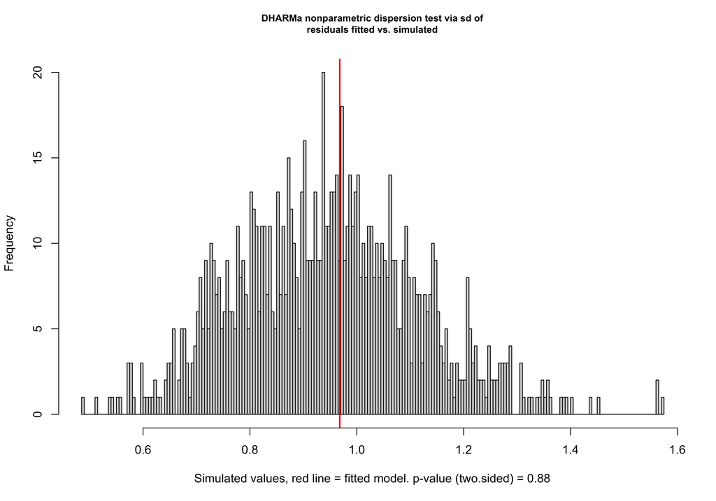

```
##
##  DHARMa nonparametric dispersion test via sd of residuals fitted vs.
##  simulated
##
## data:  simulationOutput
## dispersion = 1.0236, p-value = 0.88
## alternative hypothesis: two.sided
```

```r
print(testDispersion(sim_growth_full))
```

```r
cat("\nOutlier test:\n")
```

```
##
## Outlier test:
```

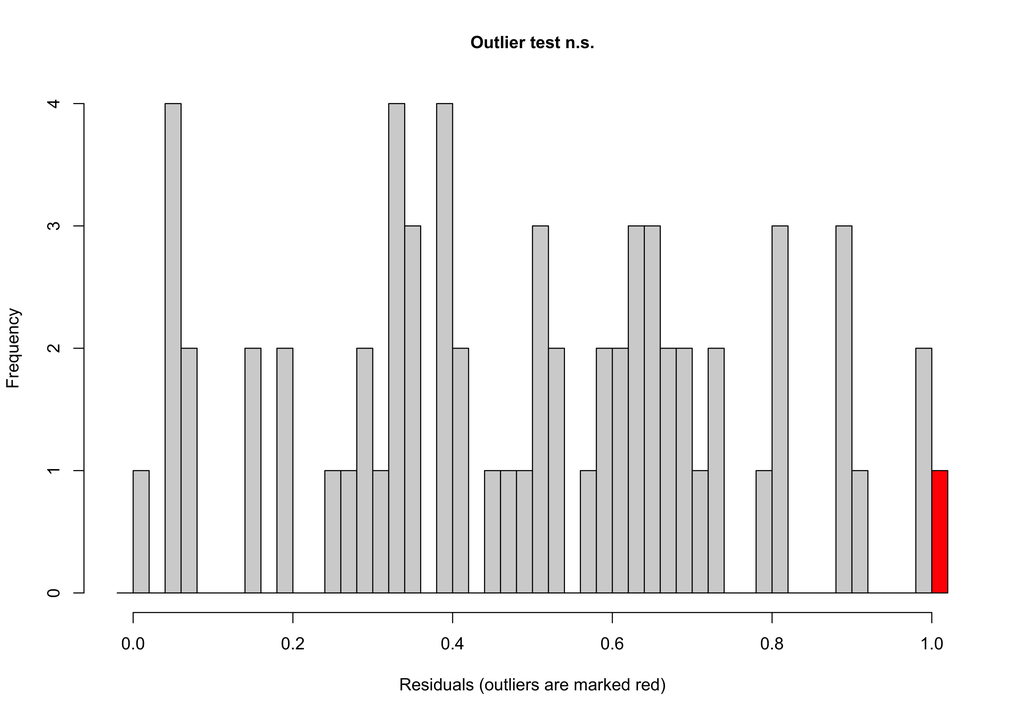

```
##
##  DHARMa outlier test based on exact binomial test with approximate
##  expectations
##
## data:  sim_growth_full
## outliers at both margin(s) = 1, observations = 66, p-value = 0.1237
## alternative hypothesis: true probability of success is not equal to 0.001998002
## 95 percent confidence interval:
##  0.0003835296 0.0815523211
## sample estimates:
## frequency of outliers (expected: 0.001998001998002 )
##                                           0.01515152
```

```r
print(testOutliers(sim_growth_full))
```

## Predicted vs Observed: Growth Model

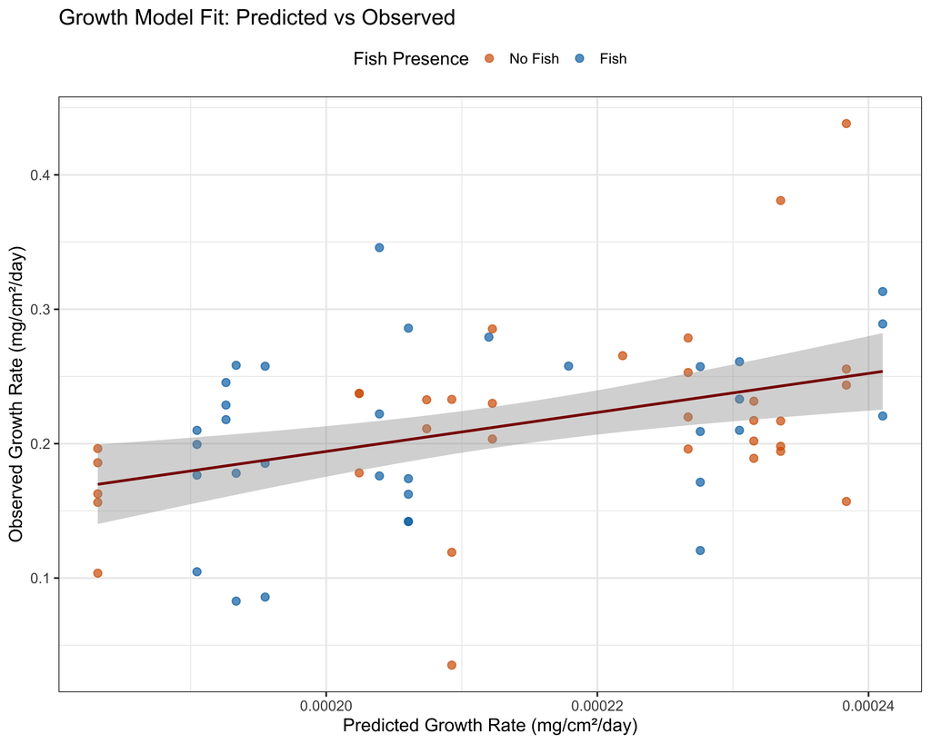

```r
bw_sa_stats$pred_growth <- predict(mod_int_sa)

p_growth_fit <- ggplot(bw_sa_stats, aes(x = pred_growth, y = bw_sa_time)) +
  geom_point(aes(color = fish), size = 2.5, alpha = 0.7) +
  geom_smooth(method = "lm", se = TRUE, color = "darkred", linewidth = 1) +
  geom_abline(intercept = 0, slope = 1, linetype = "dashed", color = "gray50") +
  scale_color_manual(values = fish_palette) +
  labs(
    x = "Predicted Growth Rate (mg/cm²/day)",
    y = "Observed Growth Rate (mg/cm²/day)",
    title = "Growth Model Fit: Predicted vs Observed",
    color = "Fish Presence"
  ) +
  theme_bw(base_size = 14) +
  theme(legend.position = "top")

print(p_growth_fit)
```

```r
ggsave(
  here("figures", "diagnostics", "growth_fit_scatterplot.png"),
  p_growth_fit,
  width = 10, height = 8, dpi = 300, bg = "white"
)
```

## DHARMa Diagnostics: Full Model (Primary Analysis)

```r
cat("\n\n=== Diagnostics for Full Model (Primary Analysis) ===\n\n")
```

```
##
##
## === Diagnostics for Full Model (Primary Analysis) ===
```

```r
sim_full <- simulateResiduals(fittedModel = model_full, n = 1000)

png(
  here("figures", "diagnostics", "growth_full_model_dharma.png"),
  width = 7, height = 6, units = "in", res = 600, bg = "white"
)
plot(sim_full, main = "DHARMa Diagnostics: Full Model with Treatment Effects")
dev.off()
```

```r
cat("\nDispersion test:\n")
```

```
##
## Dispersion test:
```

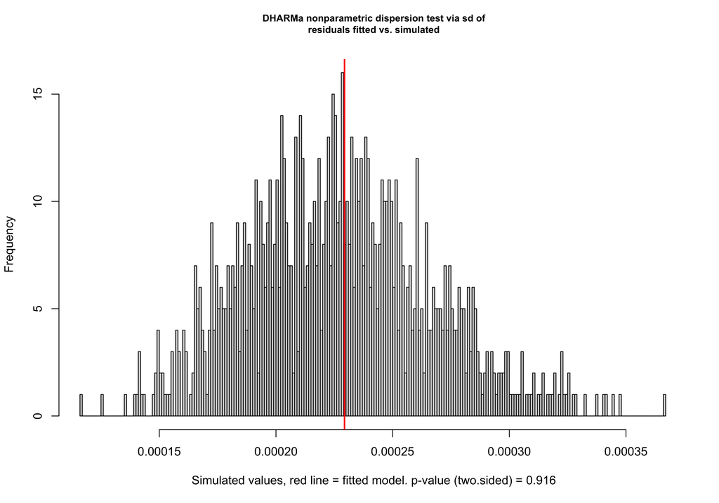

```
##
##  DHARMa nonparametric dispersion test via sd of residuals fitted vs.
##  simulated
##
## data:  simulationOutput
## dispersion = 1.0112, p-value = 0.916
## alternative hypothesis: two.sided
```

```r
print(testDispersion(sim_full))
```

```r
cat("\nOutlier test:\n")
```

```
##
## Outlier test:
```

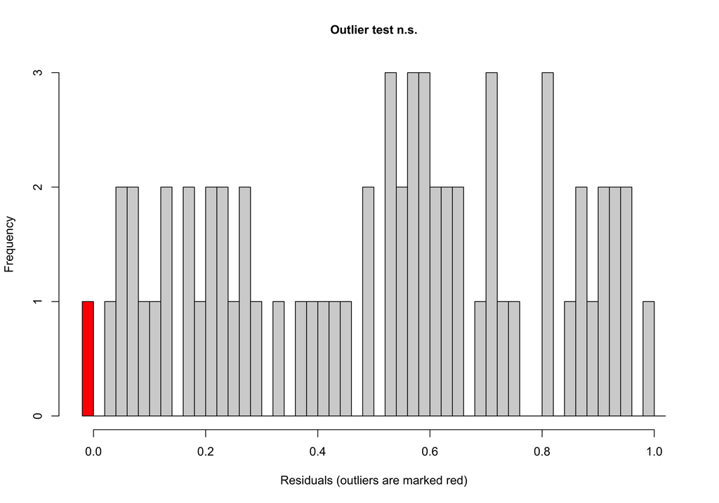

```
##
##  DHARMa outlier test based on exact binomial test with approximate
##  expectations
##
## data:  sim_full
## outliers at both margin(s) = 1, observations = 66, p-value = 0.1237
## alternative hypothesis: true probability of success is not equal to 0.001998002
## 95 percent confidence interval:
##  0.0003835296 0.0815523211
## sample estimates:
## frequency of outliers (expected: 0.001998001998002 )
##                                           0.01515152
```

```r
print(testOutliers(sim_full))
```

## Model Summary Statistics

```r
cat("\n=== Growth Model Diagnostics Summary ===\n")
```

```
##
## === Growth Model Diagnostics Summary ===
```

```r
cat("Residual standard deviation:", sigma(mod_int_sa), "\n")
```

```
## Residual standard deviation: 6.299971e-05
```

```r
cat("Number of observations:", nobs(mod_int_sa), "\n")
```

```
## Number of observations: 66
```

```r
cat("\nResidual summary:\n")
```

```
##
## Residual summary:
```

```r
print(summary(residuals(mod_int_sa, type = "pearson")))
```

```
##       Min.    1st Qu.     Median       Mean    3rd Qu.       Max.
## -1.741e-04 -3.041e-05  1.335e-06  0.000e+00  3.374e-05  1.998e-04
```

# 9. Combined Figure: Growth Rate & Photosynthetic Efficiency

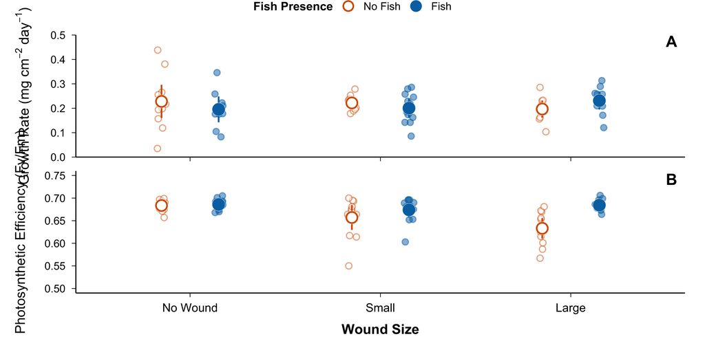

```r
# Load PAM data for combined figure
pam_data <- read.csv(here("data", "pam_undisturbed_healed_tissue_wound_no_wound.csv"))

# Prepare PAM data with proper factor levels
pam_data <- pam_data %>%
  mutate(
    fish = factor(fish, levels = c("No Fish", "Fish")),
    wound = factor(wound, levels = c("No Wound", "Small", "Large"))
  )

# Calculate PAM summary statistics
pam_summary <- pam_data %>%
  group_by(wound, fish) %>%
  summarize(
    mean_val = mean(fv_fm),
    sd_val = sd(fv_fm),
    n = n(),
    se = sd_val / sqrt(n),
    ci = qt(0.975, df = n - 1) * se,
    ci_lower = mean_val - ci,
    ci_upper = mean_val + ci,
    .groups = "drop"
  )

# Gap size for PAM plot
gap_size_pam <- 0.004

# Create PAM plot (Panel B)
pam_plot <- pam_data %>%
  ggplot(aes(x = wound, y = fv_fm, color = fish, fill = fish, shape = fish)) +

  # Individual data points
  geom_jitter(
    position = position_jitterdodge(jitter.width = 0.1, dodge.width = 0.6),
    size = 2.5,
    alpha = 0.5,
    stroke = 0.8
  ) +

  # Lower whisker
  geom_segment(
    data = pam_summary,
    aes(x = as.numeric(wound) + ifelse(fish == "No Fish", -0.15, 0.15),
        xend = as.numeric(wound) + ifelse(fish == "No Fish", -0.15, 0.15),
        y = ci_lower, yend = mean_val - gap_size_pam,
        color = fish),
    linewidth = 0.8,
    inherit.aes = FALSE,
    show.legend = FALSE
  ) +

  # Upper whisker
  geom_segment(
    data = pam_summary,
    aes(x = as.numeric(wound) + ifelse(fish == "No Fish", -0.15, 0.15),
        xend = as.numeric(wound) + ifelse(fish == "No Fish", -0.15, 0.15),
        y = mean_val + gap_size_pam, yend = ci_upper,
        color = fish),
    linewidth = 0.8,
    inherit.aes = FALSE,
    show.legend = FALSE
  ) +

  # White outline behind mean points
  geom_point(
    data = pam_summary,
    aes(x = as.numeric(wound) + ifelse(fish == "No Fish", -0.15, 0.15),
        y = mean_val),
    size = 5.5,
    color = "white",
    inherit.aes = FALSE,
    show.legend = FALSE
  ) +

  # Mean points
  geom_point(
    data = pam_summary,
    aes(x = as.numeric(wound) + ifelse(fish == "No Fish", -0.15, 0.15),
        y = mean_val, color = fish, fill = fish, shape = fish),
    size = 4.5,
    stroke = 1.2,
    inherit.aes = FALSE
  ) +

  # Scales
  scale_color_manual(
    values = c("No Fish" = "#D55E00", "Fish" = "#0072B2"),
    name = "Fish Presence"
  ) +
  scale_fill_manual(
    values = c("No Fish" = "white", "Fish" = "#0072B2"),
    name = "Fish Presence"
  ) +
  scale_shape_manual(
    values = c("No Fish" = 21, "Fish" = 21),
    name = "Fish Presence"
  ) +
  scale_y_continuous(
    limits = c(0.5, 0.75),
    breaks = seq(0.5, 0.75, by = 0.05),
    expand = c(0, 0.01)
  ) +

  # Theme
  labs(
    y = "Photosynthetic Efficiency (Fv/Fm)",
    x = "Wound Size"
  ) +
  theme_minimal(base_size = 14) +
  theme(
    panel.grid = element_blank(),
    axis.title.x = element_text(size = 14, face = "bold", margin = margin(t = 10)),
    axis.title.y = element_text(size = 14, margin = margin(r = 10)),  # Unbolded
    axis.text.x = element_text(size = 12, color = "black"),
    axis.text.y = element_text(size = 11, color = "black"),
    legend.position = "none",
    axis.line = element_line(color = "black", linewidth = 0.5),
    axis.ticks = element_line(color = "black", linewidth = 0.3),
    axis.ticks.length = unit(0.15, "cm"),
    plot.margin = margin(10, 15, 10, 10)
  )

# Modify growth plot for combined figure (Panel A - top, no x-axis labels but keep ticks)
growth_plot_combined <- growth_rate_plot +
  theme(
    legend.position = "none",
    axis.title.x = element_blank(),  # Remove x-axis title (shared with bottom panel)
    axis.text.x = element_blank(),   # Remove x-axis labels (shared with bottom panel)
    # Keep axis.ticks.x - ticks should remain visible
    axis.title.y = element_text(size = 14, margin = margin(r = 10)),  # Unbolded
    axis.text.y = element_text(size = 11, color = "black"),
    plot.margin = margin(10, 15, 5, 10)  # Reduce bottom margin
  )

# Modify PAM plot for combined figure (Panel B - bottom, with x-axis label)
pam_plot_combined <- pam_plot +
  theme(
    axis.title.x = element_text(size = 14, face = "bold", margin = margin(t = 10)),
    axis.title.y = element_text(size = 14, margin = margin(r = 10)),  # Unbolded
    axis.text.x = element_text(size = 12, color = "black"),
    axis.text.y = element_text(size = 11, color = "black"),
    plot.margin = margin(5, 15, 10, 10)  # Reduce top margin
  )

# Combine plots using patchwork - VERTICAL layout (shared x-axis)
library(patchwork)

combined_plot <- (growth_plot_combined / pam_plot_combined) +
  plot_annotation(tag_levels = 'A') &
  theme(
    plot.tag = element_text(size = 16, face = "bold"),
    plot.tag.position = c(0.98, 0.95)  # Position tags on right side
  )

# Add shared legend at top
# Extract legend from one of the plots
legend_plot <- growth_rate_plot +
  theme(
    legend.position = "top",
    legend.title = element_text(size = 12, face = "bold"),
    legend.text = element_text(size = 11)
  )

legend <- cowplot::get_legend(legend_plot)

# Final combined figure with legend
final_combined <- cowplot::plot_grid(
  legend,
  combined_plot,
  ncol = 1,
  rel_heights = c(0.06, 1)
)

print(final_combined)
```

```r
# Save combined figure
ggsave(
  filename = here("figures", "combined_growth_pam_figure.pdf"),
  plot = final_combined,
  width = 7,
  height = 8,
  dpi = 600,
  device = cairo_pdf
)

ggsave(
  filename = here("figures", "combined_growth_pam_figure.png"),
  plot = final_combined,
  width = 7,
  height = 8,
  dpi = 300,
  bg = "white"
)

cat("✓ Combined 2-panel figure saved:\n")
```

```
## ✓ Combined 2-panel figure saved:
```

```r
cat("  - PDF: figures/combined_growth_pam_figure.pdf\n")
```

```
##   - PDF: figures/combined_growth_pam_figure.pdf
```

```r
cat("  - PNG: figures/combined_growth_pam_figure.png\n")
```

```
##   - PNG: figures/combined_growth_pam_figure.png
```

**Analysis Complete** ✓

All figures and diagnostics saved to `figures/` directory.